# Predicting Breast Cancer

```python
# Importing required Libraries


import numpy as np
import pandas as pd
import matplotlib.pyplot as plt
import seaborn as sns

from scipy.stats import chi2_contingency
from scipy.stats import stats
import statistics as st

from sklearn.preprocessing import LabelEncoder



### Classifiers and Predictions
from sklearn.impute import KNNImputer
from sklearn.tree import DecisionTreeClassifier
from sklearn.preprocessing import StandardScaler
from sklearn.model_selection import cross_validate
from sklearn.model_selection import RandomizedSearchCV
from sklearn.ensemble import RandomForestClassifier, GradientBoostingClassifier

from sklearn.neighbors import KNeighborsClassifier
```

### Loading the Dataset

```python
df = pd.read_csv("C:/Users/HP/Desktop/DataSolution Lab/Breat Cancer/Breast Cancer METABRIC.csv")
df.shape #to know the number of columns and rows
```

```
(2509, 34)
```

## Data Cleaning

```python
df.isnull().sum()
```

```
Patient ID                          0
Age at Diagnosis                   11
Type of Breast Surgery            554
Cancer Type                         0
Cancer Type Detailed                0
Cellularity                       592
Chemotherapy                      529
Pam50 + Claudin-low subtype       529
Cohort                             11
ER status measured by IHC          83
ER Status                          40
Neoplasm Histologic Grade         121
HER2 status measured by SNP6      529
HER2 Status                       529
Tumor Other Histologic Subtype    135
Hormone Therapy                   529
Inferred Menopausal State         529
Integrative Cluster               529
Primary Tumor Laterality          639
Lymph nodes examined positive     266
Mutation Count                    152
Nottingham prognostic index       222
Oncotree Code                       0
Overall Survival (Months)         528
Overall Survival Status           528
PR Status                         529
Radio Therapy                     529
Relapse Free Status (Months)      121
Relapse Free Status                21
Sex                                 0
3-Gene classifier subtype         745
Tumor Size                        149
Tumor Stage                       721
Patient's Vital Status            529
dtype: int64
```

Above figures in each column names are the amount of missing values in the dataset per each column

```python
cat_columns = [2,3,4,5,6,7,8,9,10,12,13,14,15,16,17,18,22,25,26,28,29,30,32]
# df.iloc[:, cat_columns] = df.iloc[:, cat_columns].astype('category')
```

```python
df.info()
```

```
<class 'pandas.core.frame.DataFrame'>
RangeIndex: 2509 entries, 0 to 2508
Data columns (total 34 columns):
 #   Column                          Non-Null Count  Dtype
---  ------                          --------------  -----
 0   Patient ID                      2509 non-null   object
 1   Age at Diagnosis                2498 non-null   float64
 2   Type of Breast Surgery          1955 non-null   object
 3   Cancer Type                     2509 non-null   object
 4   Cancer Type Detailed            2509 non-null   object
 5   Cellularity                     1917 non-null   object
 6   Chemotherapy                    1980 non-null   object
 7   Pam50 + Claudin-low subtype     1980 non-null   object
 8   Cohort                          2498 non-null   float64
 9   ER status measured by IHC       2426 non-null   object
```

[output cut: 26 more lines]

### Filling the missing values with "forward-filling method" for all X-features

```python
# # # Event and duration columns
# df['Relapse Free Status'] = df.groupby(['Cancer Type Detailed'])['Relapse Free Status'].fillna(df['Relapse Free Status'].mode()[0])
# df['Relapse Free Status (Months)'] = df.groupby(['Cancer Type Detailed', 'Relapse Free Status'])['Relapse Free Status (Months)'].fillna(df['Relapse Free Status (Months)'].mean(axis=0))
# #df['Overall Survival Status'] = df.groupby(['Cancer Type Detailed', 'Relapse Free Status'])['Overall Survival Status'].apply(lambda x: x.fillna(x.mode()))
# df['Overall Survival (Months)'] = df.groupby(['Cancer Type Detailed', 'Overall Survival Status'])['Overall Survival (Months)'].fillna(df['Overall Survival (Months)'].mean(axis=0))


for a in df.iloc[:, df.columns != 'Overall Survival Status']:
    df[a]= df[a].fillna(method="ffill")
    df[a]= df[a].fillna(method="bfill")
```

We need to drop the "Patient's Vital Status" column since its the same as "Overall Survival Status" column

```python
 df.drop("Patient's Vital Status", axis =1, inplace=True)
```

```python
df.isnull().sum()
```

```
Patient ID                          0
Age at Diagnosis                    0
Type of Breast Surgery              0
Cancer Type                         0
Cancer Type Detailed                0
Cellularity                         0
Chemotherapy                        0
Pam50 + Claudin-low subtype         0
Cohort                              0
ER status measured by IHC           0
ER Status                           0
Neoplasm Histologic Grade           0
HER2 status measured by SNP6        0
HER2 Status                         0
Tumor Other Histologic Subtype      0
Hormone Therapy                     0
Inferred Menopausal State           0
Integrative Cluster                 0
Primary Tumor Laterality            0
Lymph nodes examined positive       0
Mutation Count                      0
Nottingham prognostic index         0
Oncotree Code                       0
Overall Survival (Months)           0
Overall Survival Status           528
PR Status                           0
Radio Therapy                       0
Relapse Free Status (Months)        0
Relapse Free Status                 0
Sex                                 0
3-Gene classifier subtype           0
Tumor Size                          0
Tumor Stage                         0
dtype: int64
```

Now all missing values have been filled, except for only Overall Survival status which is our target vaiable to predict and estimate the survival analysis on

## Exploratory Data Analysis

```python
df.describe()#.to_csv("summary.csv")
```

|  | Age at Diagnosis | Cohort | Neoplasm Histologic Grade | Lymph nodes examined positive | Mutation Count | Nottingham prognostic index | Overall Survival (Months) | Relapse Free Status (Months) | Tumor Size | Tumor Stage |
| --- | --- | --- | --- | --- | --- | --- | --- | --- | --- | --- |
| count | 2509.000000 | 2509.000000 | 2509.000000 | 2509.000000 | 2509.000000 | 2509.000000 | 2509.000000 | 2509.000000 | 2509.000000 | 2509.000000 |
| mean | 60.419414 | 2.893982 | 2.414906 | 1.889597 | 5.519729 | 4.025027 | 141.291736 | 106.110965 | 27.002798 | 1.724990 |
| std | 13.026546 | 1.962548 | 0.647373 | 3.942895 | 3.964972 | 1.197194 | 74.476362 | 76.661751 | 16.479847 | 0.621339 |
| min | 21.930000 | 1.000000 | 1.000000 | 0.000000 | 1.000000 | 1.000000 | 0.000000 | 0.000000 | 1.000000 | 0.000000 |
| 25% | 50.920000 | 1.000000 | 2.000000 | 0.000000 | 3.000000 | 3.050000 | 76.233333 | 37.010000 | 17.000000 | 1.000000 |
| 50% | 61.140000 | 3.000000 | 3.000000 | 0.000000 | 5.000000 | 4.048000 | 148.066667 | 97.600000 | 23.000000 | 2.000000 |
| 75% | 70.000000 | 4.000000 | 3.000000 | 2.000000 | 7.000000 | 5.040000 | 201.900000 | 163.260000 | 30.000000 | 2.000000 |
| max | 96.290000 | 9.000000 | 3.000000 | 45.000000 | 80.000000 | 7.200000 | 355.200000 | 384.210000 | 182.000000 | 4.000000 |

### Summary grouped bu Over all survial status

```python
df.groupby("Overall Survival Status").mean()#.to_csv("Grouped by mean summary.csv")
```

| Overall Survival Status | Age at Diagnosis | Cohort | Neoplasm Histologic Grade | Lymph nodes examined positive | Mutation Count | Nottingham prognostic index | Overall Survival (Months) | Relapse Free Status (Months) | Tumor Size | Tumor Stage |
| --- | --- | --- | --- | --- | --- | --- | --- | --- | --- | --- |
| Deceased | 64.443645 | 2.782343 | 2.468531 | 2.602273 | 5.923077 | 4.152206 | 100.443007 | 83.669292 | 28.380935 | 1.857517 |
| Living | 56.499152 | 2.396655 | 2.347670 | 1.212664 | 5.258065 | 3.817950 | 159.142294 | 146.160956 | 23.379892 | 1.679809 |

### Summary of categorical variables

```python
df.describe(include='object')
```

|  | Patient ID | Type of Breast Surgery | Cancer Type | Cancer Type Detailed | Cellularity | Chemotherapy | Pam50 + Claudin-low subtype | ER status measured by IHC | ER Status | HER2 status measured by SNP6 | ... | Inferred Menopausal State | Integrative Cluster | Primary Tumor Laterality | Oncotree Code | Overall Survival Status | PR Status | Radio Therapy | Relapse Free Status | Sex | 3-Gene classifier subtype |
| --- | --- | --- | --- | --- | --- | --- | --- | --- | --- | --- | --- | --- | --- | --- | --- | --- | --- | --- | --- | --- | --- |
| count | 2509 | 2509 | 2509 | 2509 | 2509 | 2509 | 2509 | 2509 | 2509 | 2509 | ... | 2509 | 2509 | 2509 | 2509 | 1981 | 2509 | 2509 | 2509 | 2509 | 2509 |
| unique | 2509 | 2 | 2 | 8 | 3 | 2 | 7 | 2 | 2 | 4 | ... | 2 | 11 | 2 | 8 | 2 | 2 | 2 | 2 | 1 | 4 |
| top | MB-0000 | Breast Conserving | Breast Cancer | Breast Invasive Ductal Carcinoma | High | No | LumB | Positve | Positive | Neutral | ... | Post | 10 | Left | IDC | Deceased | Negative | Yes | Not Recurred | Female | ER+/HER2- High Prolif |
| freq | 1 | 1319 | 2506 | 1865 | 1522 | 2096 | 1001 | 1865 | 1841 | 1965 | ... | 2084 | 751 | 1550 | 1865 | 1144 | 1466 | 1701 | 1497 | 2509 | 1238 |

4 rows × 23 columns

## Univariate Visualizations

### Histogram for Age

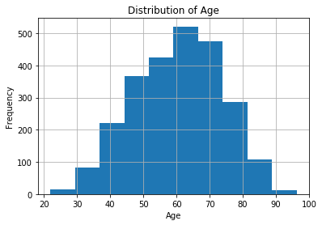

```python
ps = df["Age at Diagnosis"].hist()
ps.set_xlabel('Age')
ps.set_ylabel('Frequency')
ps.set_title('Distribution of Age')
```

### Distribution of Gender

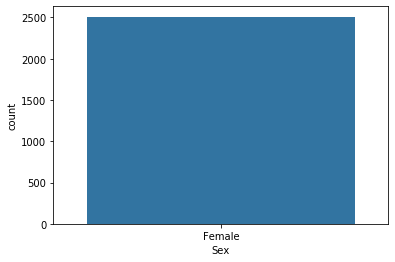

```python
sns.countplot('Sex', data = df)
```

Very obvious all the respondents are Females

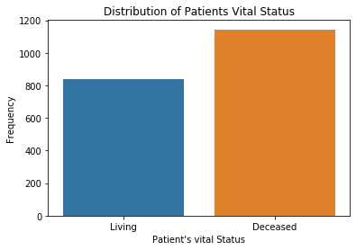

```python
sns.countplot( x = "Overall Survival Status", data=df)
plt.xlabel("Patient's vital Status")
plt.ylabel("Frequency")
plt.title("Distribution of Patients Vital Status")
plt.show()
```

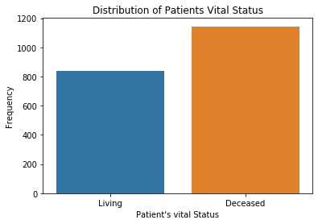

```python
sns.countplot( x = "Overall Survival Status", data=df)
plt.xlabel("Patient's vital Status")
plt.ylabel("Frequency")
plt.title("Distribution of Patients Vital Status")
plt.show()
```

### Distribution of Cancer Type

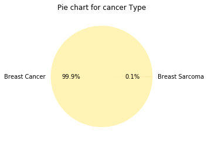

```python
plt.pie(df['Cancer Type'].value_counts(), labels = ["Breast Cancer", "Breast Sarcoma"], colors = sns.color_palette("YlOrBr"), autopct = '%1.1f%%')
plt.title("Pie chart for cancer Type")
plt.show()
pass
```

## Bi/Multi- Variate Visualizations

### Patient Vital Status with respect to HER2 status

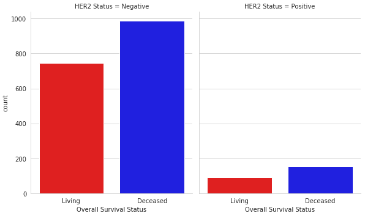

```python
sns.set_palette("bright")

with sns.axes_style(style='whitegrid'):
    g = sns.catplot("Overall Survival Status", col="HER2 Status", col_wrap=3, data=df, kind="count", height=5.0, aspect=0.80, palette=['Red', 'Blue'])
```

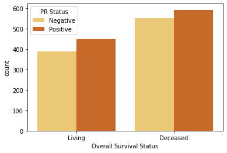

```python
sns.countplot(x = "Overall Survival Status", hue = 'PR Status', palette = "YlOrBr", data = df)
plt.show()
```

## Relationships of the variables

```python
corr_mat = df.corr()
corr_mat.to_csv("correlation.csv")
```

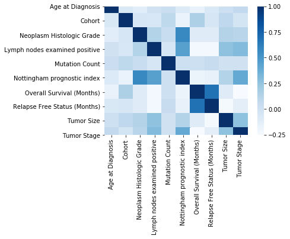

```python
sns.heatmap(corr_mat, square = True, cmap = 'Blues')
pass
```

# Part 2

## Structuring the data to train and test Predictive Model

### Filtering Testing and training dataset from the dataset (all target mising rows)

#### Note:

The train data will be all the rows with non-empty values of our target variable, that is, since overall Survival Status is our target variable with 528 rows of missing values, the train data will then be all the rows where Survival status is not empty, while the test data will thn be all the rows where survival status is empty so we can train the training data and use it t predict the test data where the target values are missing.

```python
df.head()
print(df.shape)
```

```
(2509, 33)
```

```python
df["Overall Survival Status"].unique()
```

```
array(['Living', 'Deceased', nan], dtype=object)
```

```python
for b in df.iloc[:, cat_columns]:
    df[b]= LabelEncoder().fit_transform(df[b]) ##  This will automaticaly recode the categorical values to figures, e.g - yes - 1 and no - 0
```

```python
df
```

|  | Patient ID | Age at Diagnosis | Type of Breast Surgery | Cancer Type | Cancer Type Detailed | Cellularity | Chemotherapy | Pam50 + Claudin-low subtype | Cohort | ER status measured by IHC | ... | Overall Survival (Months) | Overall Survival Status | PR Status | Radio Therapy | Relapse Free Status (Months) | Relapse Free Status | Sex | 3-Gene classifier subtype | Tumor Size | Tumor Stage |
| --- | --- | --- | --- | --- | --- | --- | --- | --- | --- | --- | --- | --- | --- | --- | --- | --- | --- | --- | --- | --- | --- |
| 0 | MB-0000 | 75.65 | 1 | 0 | 2 | 0 | 0 | 6 | 0 | 1 | ... | 140.500000 | Living | 0 | 1 | 138.65 | 0 | 0 | 2 | 22.0 | 2 |
| 1 | MB-0002 | 43.19 | 0 | 0 | 2 | 0 | 0 | 2 | 0 | 1 | ... | 84.633333 | Living | 1 | 1 | 83.52 | 0 | 0 | 0 | 10.0 | 1 |
| 2 | MB-0005 | 48.87 | 1 | 0 | 2 | 0 | 1 | 3 | 0 | 1 | ... | 163.700000 | Deceased | 1 | 0 | 151.28 | 1 | 0 | 0 | 15.0 | 2 |
| 3 | MB-0006 | 47.68 | 1 | 0 | 5 | 2 | 1 | 3 | 0 | 1 | ... | 164.933333 | Living | 1 | 1 | 162.76 | 0 | 0 | 0 | 25.0 | 2 |
| 4 | MB-0008 | 76.97 | 1 | 0 | 5 | 0 | 1 | 3 | 0 | 1 | ... | 41.366667 | Deceased | 1 | 1 | 18.55 | 1 | 0 | 0 | 40.0 | 2 |
| ... | ... | ... | ... | ... | ... | ... | ... | ... | ... | ... | ... | ... | ... | ... | ... | ... | ... | ... | ... | ... | ... |
| 2504 | MTS-T2428 | 70.05 | 0 | 0 | 6 | 0 | 0 | 3 | 0 | 1 | ... | 201.900000 | NaN | 0 | 1 | 4.93 | 1 | 0 | 0 | 27.0 | 1 |
| 2505 | MTS-T2429 | 63.60 | 0 | 0 | 6 | 0 | 0 | 3 | 0 | 1 | ... | 201.900000 | NaN | 0 | 1 | 16.18 | 1 | 0 | 0 | 28.0 | 2 |
| 2506 | MTS-T2430 | 63.60 | 0 | 0 | 6 | 0 | 0 | 3 | 0 | 1 | ... | 201.900000 | NaN | 0 | 1 | 16.18 | 1 | 0 | 0 | 28.0 | 0 |
| 2507 | MTS-T2431 | 63.60 | 0 | 0 | 6 | 0 | 0 | 3 | 0 | 1 | ... | 201.900000 | NaN | 0 | 1 | 16.18 | 1 | 0 | 0 | 28.0 | 0 |
| 2508 | MTS-T2432 | 63.60 | 0 | 0 | 6 | 0 | 0 | 3 | 0 | 1 | ... | 201.900000 | NaN | 0 | 1 | 16.18 | 1 | 0 | 0 | 28.0 | 0 |

2509 rows × 33 columns

## Now lets split the data manually

```python
train = df[df["Overall Survival Status"].notnull()]
train["Overall Survival Status"]= LabelEncoder().fit_transform(train["Overall Survival Status"])
# train.to_csv('actual_train.csv')
train.info()
```

```
<class 'pandas.core.frame.DataFrame'>
Int64Index: 1981 entries, 0 to 1984
Data columns (total 33 columns):
 #   Column                          Non-Null Count  Dtype
---  ------                          --------------  -----
 0   Patient ID                      1981 non-null   object
 1   Age at Diagnosis                1981 non-null   float64
 2   Type of Breast Surgery          1981 non-null   int32
 3   Cancer Type                     1981 non-null   int32
 4   Cancer Type Detailed            1981 non-null   int32
 5   Cellularity                     1981 non-null   int32
 6   Chemotherapy                    1981 non-null   int32
 7   Pam50 + Claudin-low subtype     1981 non-null   int32
 8   Cohort                          1981 non-null   int64
 9   ER status measured by IHC       1981 non-null   int32
```

[output cut: 25 more lines]

```python
test = df[df["Overall Survival Status"].isnull()]
# test.to_csv('actual_test.csv')
test.info()
```

```
<class 'pandas.core.frame.DataFrame'>
Int64Index: 528 entries, 9 to 2508
Data columns (total 33 columns):
 #   Column                          Non-Null Count  Dtype
---  ------                          --------------  -----
 0   Patient ID                      528 non-null    object
 1   Age at Diagnosis                528 non-null    float64
 2   Type of Breast Surgery          528 non-null    int32
 3   Cancer Type                     528 non-null    int32
 4   Cancer Type Detailed            528 non-null    int32
 5   Cellularity                     528 non-null    int32
 6   Chemotherapy                    528 non-null    int32
 7   Pam50 + Claudin-low subtype     528 non-null    int32
 8   Cohort                          528 non-null    int64
 9   ER status measured by IHC       528 non-null    int32
```

[output cut: 25 more lines]

# Building the Model

```python
train = pd.read_csv("C:/Users/HP/Desktop/DataSolution Lab/Breat Cancer/train_data.csv")
test = pd.read_csv("C:/Users/HP/Desktop/DataSolution Lab/Breat Cancer/test.csv")
```

```python
train.drop(['Unnamed: 0', 'Patient ID'], axis=1, inplace=True)
test.drop(['Unnamed: 0', 'Patient ID'], axis=1, inplace=True)
```

```python
print(train.shape)
print(test.shape)
```

```
(1981, 32)
(528, 32)
```

### Spliting the set

```python
### Train data

x_train = train.iloc[:, train.columns != 'Overall Survival Status'].values
y_train = train.iloc[:, train.columns == 'Overall Survival Status'].values


### test data
x_test = test.iloc[:, test.columns != 'Overall Survival Status'].values
```

```python
y_train
```

```
array([[1],
       [1],
       [0],
       ...,
       [0],
       [0],
       [0]], dtype=int64)
```

```python
from sklearn.preprocessing import StandardScaler
sc = StandardScaler()
x_train = sc.fit_transform(x_train)
x_test = sc.transform(x_test)
```

# Random Forest Classifier

```python
RF = RandomForestClassifier(random_state=0)
RF.fit(x_train, y_train)

print("model score: ", RF.score(x_train, y_train))

pred = RF.predict(x_test)
```

```
model score:  1.0
```

```python
pred_log = RF.predict_proba(x_test)
pre = pd.DataFrame(pred_log).to_csv("probabilty_prediction.csv")
```

```python
prediction = pd.DataFrame(pred)
prediction.to_csv("prediction.csv")
```

```python
test.drop("Overall Survival Status", axis=1, inplace=True)
```

```python
feature_imp = pd.Series(RF.feature_importances_, index=test.columns).sort_values(ascending=False)
feature_imp#.to_csv("Importance.csv")
```

```
Relapse Free Status               0.154055
Age at Diagnosis                  0.141656
Relapse Free Status (Months)      0.123537
Overall Survival (Months)         0.115281
Nottingham prognostic index       0.059104
Tumor Size                        0.049420
Cohort                            0.043654
Mutation Count                    0.039854
Integrative Cluster               0.033065
Pam50 + Claudin-low subtype       0.025950
Lymph nodes examined positive     0.023487
3-Gene classifier subtype         0.018556
Neoplasm Histologic Grade         0.014185
Inferred Menopausal State         0.013935
Type of Breast Surgery            0.013390
Cellularity                       0.012751
Tumor Other Histologic Subtype    0.011444
Oncotree Code                     0.010774
HER2 status measured by SNP6      0.010773
Tumor Stage                       0.010704
Primary Tumor Laterality          0.010110
Chemotherapy                      0.010020
Radio Therapy                     0.009875
Cancer Type Detailed              0.009637
PR Status                         0.009459
Hormone Therapy                   0.008685
ER Status                         0.006475
ER status measured by IHC         0.005875
HER2 Status                       0.004260
Cancer Type                       0.000028
Sex                               0.000000
dtype: float64
```

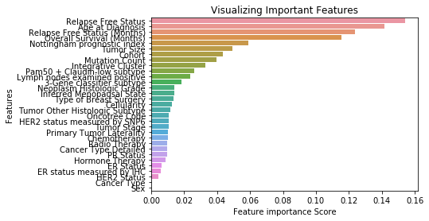

```python
%matplotlib inline

sns.barplot(x=feature_imp, y=feature_imp.index)
plt.xlabel("Feature importance Score")
plt.ylabel("Features")
plt.title("Visualizing Important Features")

plt.show()
```

```python
# from sklearn.metrics import classification_report, confusion_matrix
# # print(classification_report(,pred))
```

# Logistics Regression

```python
from sklearn.linear_model import LogisticRegression
model = LogisticRegression()
model.fit(x_train, y_train)

print("model score: ", model.score(x_train, y_train))

pred = model.predict(x_test)
```

```
model score:  0.8278647147905098
```

Checking the model score of RandomForest classifier and Logistics Regression classifier, the accuracy of Random forest seems to be 100% while that of logistic regression is 82%. Therefore, Randomforest model will be used for prediction

# Part 3

## Survival Analysis

```python
df2 = pd.read_csv("C:/Users/HP/Desktop/DataSolution Lab/Breat Cancer/Raw Survival.csv")
df2.drop("Unnamed: 0", axis=1, inplace=True)
df3 = pd.read_csv("C:/Users/HP/Desktop/DataSolution Lab/Breat Cancer/Survival Data.csv")
df3.drop("Unnamed: 0", axis=1, inplace=True)
```

```python
df3.drop("Patient ID", axis=1, inplace=True)
```

```python
df3.tail()
# df3["Overall Survival Status"].unique()
```

|  | Age at Diagnosis | Type of Breast Surgery | Cancer Type | Cancer Type Detailed | Cellularity | Chemotherapy | Pam50 + Claudin-low subtype | Cohort | ER status measured by IHC | ER Status | ... | Overall Survival (Months) | Overall Survival Status | PR Status | Radio Therapy | Relapse Free Status (Months) | Relapse Free Status | Sex | 3-Gene classifier subtype | Tumor Size | Tumor Stage |
| --- | --- | --- | --- | --- | --- | --- | --- | --- | --- | --- | --- | --- | --- | --- | --- | --- | --- | --- | --- | --- | --- |
| 2504 | 70.05 | 0 | 0 | 6 | 0 | 0 | 3 | 0 | 1 | 1 | ... | 201.9 | 0 | 0 | 1 | 4.93 | 1 | 0 | 0 | 27.0 | 1 |
| 2505 | 63.60 | 0 | 0 | 6 | 0 | 0 | 3 | 0 | 1 | 1 | ... | 201.9 | 0 | 0 | 1 | 16.18 | 1 | 0 | 0 | 28.0 | 2 |
| 2506 | 63.60 | 0 | 0 | 6 | 0 | 0 | 3 | 0 | 1 | 1 | ... | 201.9 | 0 | 0 | 1 | 16.18 | 1 | 0 | 0 | 28.0 | 0 |
| 2507 | 63.60 | 0 | 0 | 6 | 0 | 0 | 3 | 0 | 1 | 1 | ... | 201.9 | 0 | 0 | 1 | 16.18 | 1 | 0 | 0 | 28.0 | 0 |
| 2508 | 63.60 | 0 | 0 | 6 | 0 | 0 | 3 | 0 | 1 | 1 | ... | 201.9 | 0 | 0 | 1 | 16.18 | 1 | 0 | 0 | 28.0 | 0 |

5 rows × 32 columns

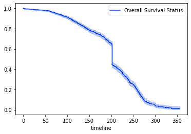

```python
from lifelines import KaplanMeierFitter
from lifelines.datasets import load_waltons

kmf = KaplanMeierFitter(label="Overall Survival Status")
kmf.fit(df2['Overall Survival (Months)'], df2['Overall Survival Status'])
kmf.plot()
```

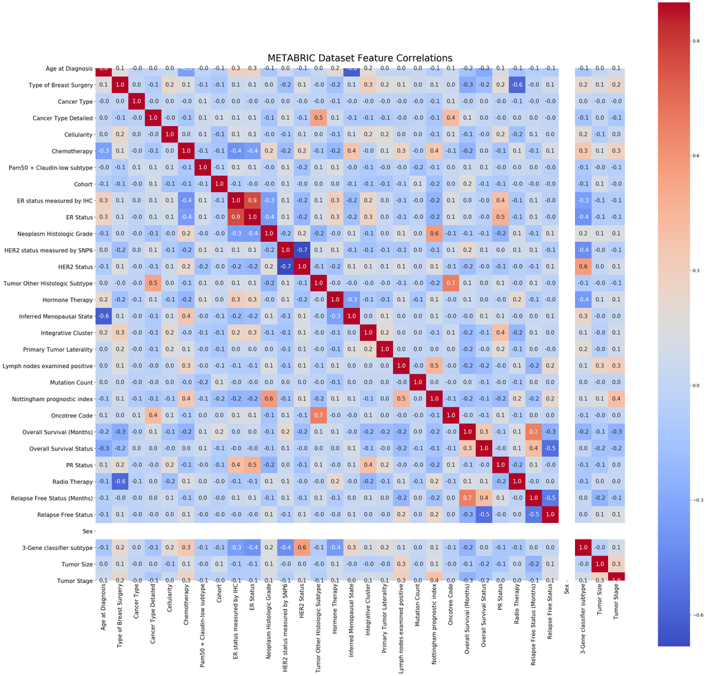

```python
fig = plt.figure(figsize=(32, 32), dpi=100)

ax = sns.heatmap(df3.corr(), annot=True, square=True, cmap='coolwarm', annot_kws={'size': 15},  fmt='.1f')
cbar = ax.collections[0].colorbar
cbar.ax.tick_params(labelsize=12)

plt.tick_params(axis='x', labelsize=15, rotation=90)
plt.tick_params(axis='y', labelsize=15, rotation=0)
plt.title('METABRIC Dataset Feature Correlations', size=25, pad=20)

plt.show()
```

```python
from sklearn.model_selection import train_test_split, StratifiedKFold
df_train, df_test = train_test_split(df3,
                                     test_size=0.2,
                                     stratify=df['Cancer Type Detailed'],
                                     shuffle=True,
                                     random_state=0)

df_train.reset_index(drop=True, inplace=True)
df_test.reset_index(drop=True, inplace=True)

n_splits = 5
skf = StratifiedKFold(n_splits=n_splits, shuffle=True, random_state=0)
for fold, (_, val_idx) in enumerate(skf.split(df_train, df_train['Cancer Type Detailed']), 1):
    df_train.loc[val_idx, 'fold'] = fold

df_train['fold'] = df_train['fold'].astype(np.uint8)
```

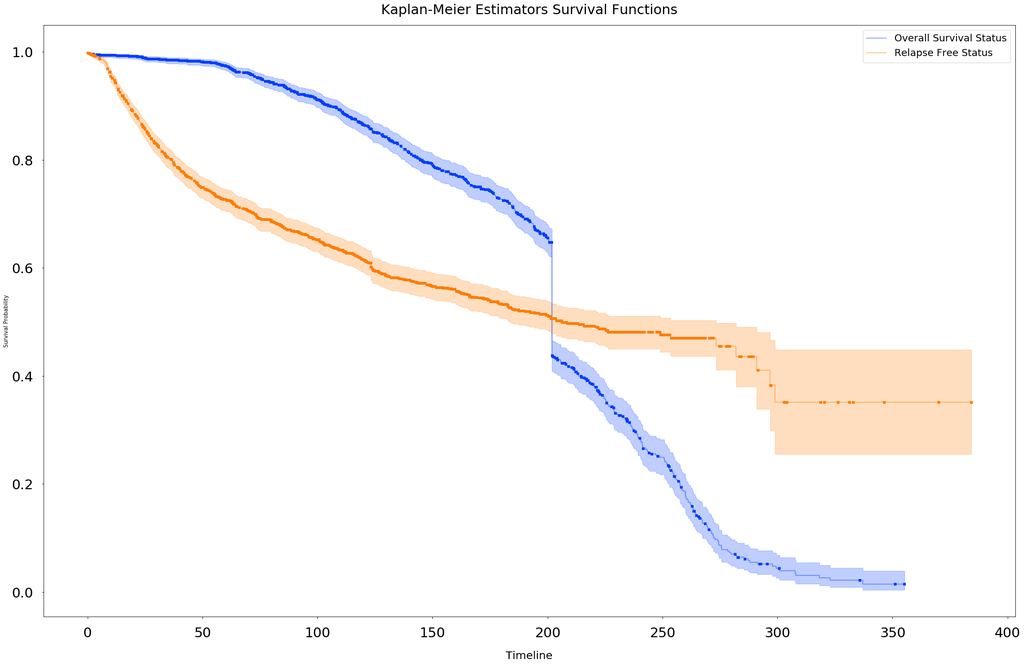

```python
fig = plt.figure(figsize=(32, 20))

for time, event in zip(['Overall Survival (Months)', 'Relapse Free Status (Months)'], ['Overall Survival Status', 'Relapse Free Status']):

    T, E = df_train[time], df_train[event]
    kmf = KaplanMeierFitter()
    kmf.fit(T, E)
    kmf.plot(label=event, alpha=0.5, show_censors=True, censor_styles={'ms': 4, 'marker': 's'})

plt.xlabel('Timeline', size=20, labelpad=20)
plt.ylabel('Survival Probability')
plt.tick_params(axis='x', labelsize=25, pad=15)
plt.tick_params(axis='y', labelsize=25, pad=15)
plt.legend(prop={'size': 18})
plt.title('Kaplan-Meier Estimators Survival Functions', size=25, pad=20)

plt.show()
```

```python
# evaluation_times = [12, 24, 36]

# for time, event in zip(['Overall Survival (Months)', 'Relapse Free Status (Months)'], ['Overall Survival Status', 'Relapse Free Status']):

#     df_oof_survival_function = pd.DataFrame(data=np.zeros((df_train.shape[0], len(evaluation_times))),
#                                                 index=df_train.index,
#                                                 columns=evaluation_times)
#     df_test_survival_function = pd.DataFrame(data=np.zeros((df_test.shape[0], len(evaluation_times))),
#                                              index=df_test.index,
#                                              columns=evaluation_times)

#     for fold in sorted(df_train['fold'].unique()):

#         trn_idx, val_idx = df_train.loc[df_train['fold'] != fold].index, df_train.loc[df_train['fold'] == fold].index
#         T_trn, E_trn = df_train.loc[trn_idx, time], df_train.loc[trn_idx, event]
#         T_val, E_val = df_train.loc[val_idx, time], df_train.loc[val_idx, event]
#         kmf = KaplanMeierFitter()
#         kmf.fit(T_trn, E_trn)

#         survival_function = kmf.predict(times=evaluation_times)
#         val_survival_function = pd.DataFrame(data=np.transpose(np.tile(survival_function.values.reshape(-1, 1), T_val.shape[0])),
#                                              index=val_idx,
#                                              columns=evaluation_times)
#         df_oof_survival_function.loc[val_idx, :] = val_survival_function.values
#         test_survival_function = pd.DataFrame(data=np.transpose(np.tile(survival_function.values.reshape(-1, 1), df_test.shape[0])),
#                                               index=df_test.index,
#                                               columns=evaluation_times)
#         df_test_survival_function += (test_survival_function.values / n_splits)

#         val_auc = time_dependent_roc_auc_score(df_train.loc[val_idx, event], val_survival_function, df_train.loc[val_idx, time])
#         print(f'Fold {fold} ({time}) - ROC AUC Scores {val_auc}')

#     oof_auc = time_dependent_roc_auc_score(df_train[event], df_oof_survival_function, df_train[time])
#     test_auc = time_dependent_roc_auc_score(df_test[event], df_test_survival_function, df_test[time])
#     print(f'{"-" * 30}\nKaplan Meier Estimate {time} OOF AUC: {oof_auc}')
#     print(f'Kaplan-Meier Estimate {time} Test AUC: {test_auc}\n{"-" * 30}\n')
```